# Annual Report Data Analysis - Question 3.07 and 3.08

Tristan Burgess and Cristin Young

2026-04-21

# 3. Did EBP/CDEP services impact clinical and functional outcomes for clients who participated?

**Inclusion criteria:** 1. must have initial time point data (i.e., be enrolled in an intervention), 2. must have a valid assessment collected at both intake and discharge time points, and 3. limited to tools with a clinical cut-off.

**Scoring:** An **increase** in score indicates a positive outcome. There are no benchmarks or clinical cutoffs established for NOMS scoring — if the follow-up assessment score is higher than the initial score, a positive outcome is indicated.

**Assumptions:** Filtered out dates before 2024-01-01 and after the date the code was run. Filtered data that’s >3 days from initial assessment and paired to the LAST follow-up. Filtered positive outcomes that had NAs before computing %.

## 3.07 To what extent did parents/caregivers report improved well-being for themselves and their child after receiving the intervention?

Range: 7–35; Sum = Q3a+…+Q3g.

Use the `pairs_primary_long_child` data frame to compute scores. The following had a positive outcome by follow-up quarter:

| positive_outcome | n | percent |
| --- | --- | --- |
| worsened | 270 | 26% |
| no_change | 252 | 24% |
| improved | 530 | 50% |

Plot it.

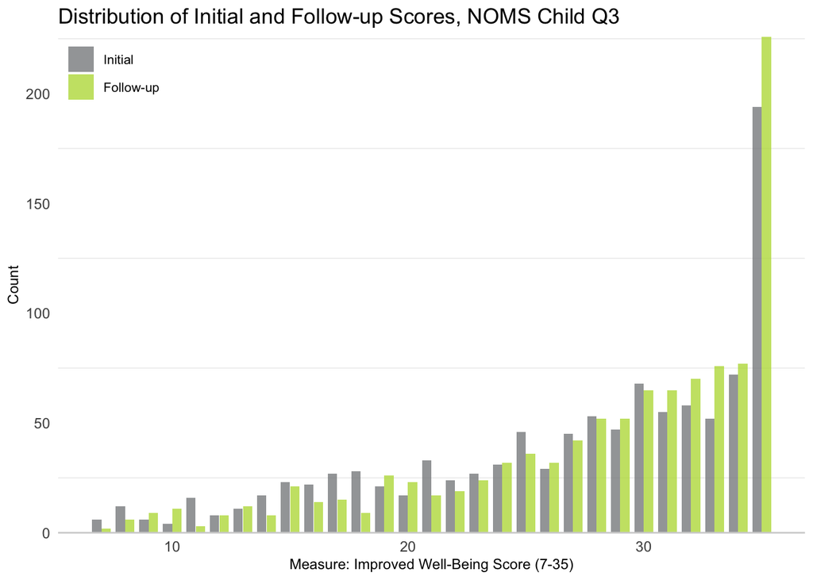

Ridgeline plot

| score_type | mean_score | median_score | sd_score | n | y_text |
| --- | --- | --- | --- | --- | --- |
| Initial | 26.98764 | 29 | 7.402191 | 1052 | 1.090 |
| Follow-up | 28.25665 | 30 | 6.894109 | 1052 | 1.095 |

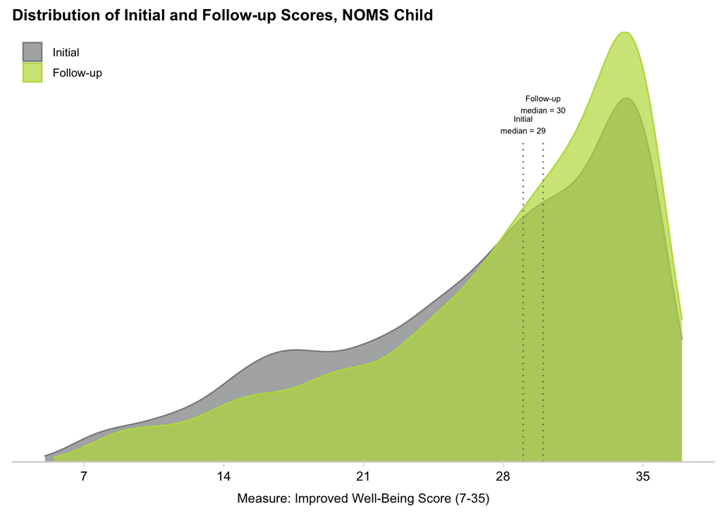

#### Summary stats

The percent of those who had total scores of 28 or higher across Q3 at initial and discharge time points were:

| initial_28 | followup_28 |
| --- | --- |
| 56.94 | 64.92 |

## 3.08 To what extent did the youth report improved well-being after receiving the intervention?

Range: 7–35; Sum = Q3a+…+Q3g.

Use the `pairs_primary_long_self` data frame to compute scores. The following had a positive outcome by follow-up quarter:

| positive_outcome | n | percent |
| --- | --- | --- |
| worsened | 1182 | 52% |
| no_change | 138 | 6% |
| improved | 971 | 42% |

Plot it.

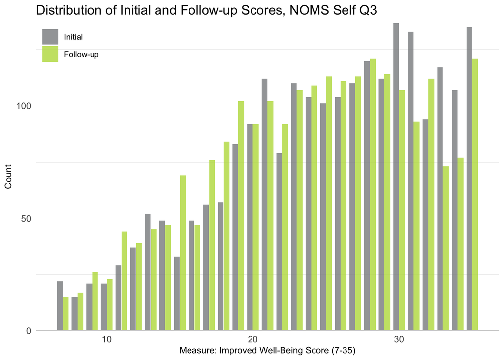

Ridgeline plot

| score_type | mean_score | median_score | sd_score | n | y_text |
| --- | --- | --- | --- | --- | --- |
| Initial | 24.81886 | 26 | 7.077667 | 2291 | 1.085 |
| Follow-up | 23.96639 | 25 | 7.030514 | 2291 | 1.090 |

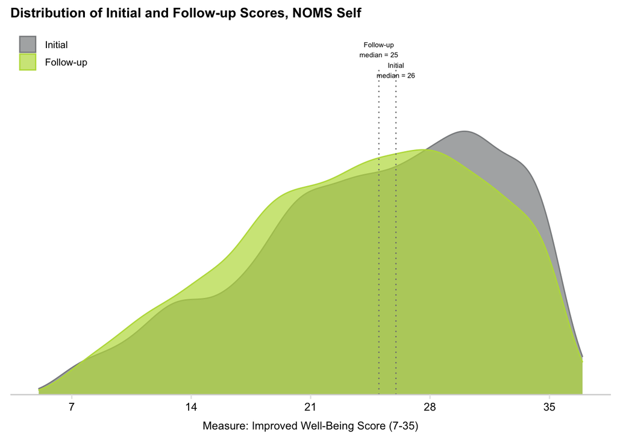

#### Summary stats

The percent of those who had total scores of 28 or higher across Q3 at initial and discharge time points were:

| initial_28 | followup_28 |
| --- | --- |
| 41.68 | 35.7 |

### Summary stats overall

[figure not shown]